# Augmented Dickey Fuller Test - Monte Carlo Simulations

# A Tale of Thousand Simulations

1. Model Identification/Specification
2. Model Estimation
3. Model Validation
4. Forecasting

# Cleaning Up the Console and Setting the Working Directory

To clean up all previously created variables and clean up console use the following:

```python
from IPython import get_ipython
get_ipython().magic('reset -sf')
get_ipython().magic('clear')
```

To change the working directory, use the following:

```python
import os
path = "enter/your/path/here/with/slash"
os.chdir(path)
```

# Importing Necessary Packages and Setting Style of Plots

The following packages are used in this analysis.

```python
# Import necessary libraries
import numpy as np
import random
import matplotlib.pyplot as plt
from statsmodels.tsa.stattools import adfuller
```

Use the following command to set the style of plots to "seaborn".

```python
plt.style.use("seaborn-v0_8")
```

# Self-written functions

In this analysis I used the following self-written functions:

Self-written function that generates AR(2) DGP that takes in autoregressive parameters, mean and variance of error terms, and sample size:

```python
#function generating ar2 dgp
def ar2gen(alpha1, alpha2, mu, sigma_sq, T):
    ar2_data = np.zeros(T+2)
    eps = np.random.normal(mu, sigma_sq, size=T)
    for ii in range(2,T+2):
        ar2_data[ii] = alpha1*ar2_data[ii-1] + alpha2*ar2_data[ii-2] + \
        eps[ii-2]
    ar2_data=ar2_data[2:]
    return ar2_data
```

```python
# Ratio function to calculate rejection frequency
def ratio(Y, threshold=-1.9441638046362444):
    numer_count = np.sum(Y < threshold)
    ratio = numer_count / len(Y)
    return numer_count, ratio
```

# ADF Test - A Little Bit of Theory

The origional article that introduced [Augmented Dickey Fuller Test](https://www.jstor.org/stable/2286348) was first published in 1979. However, here I utilise [Time Series Analysis, Chapter 17, Hamilton (1994)'s](https://press.princeton.edu/books/hardcover/9780691042893/time-series-analysis) notation.

Let us start with the following autoregressive model of order $p$:

$$y_{t}=α_{1} y_{t-1}  +   ⋯   +   α_{p} y_{t-p}   +   ε_{t} \tag{1}$$

If we subtract $y_{t-1}$ from both sides of (1) and rearrange terms, we obtain regression (2):

$$Δy_{t}=δ y_{t-1}  +   α^{*}_{1} Δy_{t-1}   +  ⋯   +   α^{*}_{p-1} Δy_{t-p+1}   +   ε_{t}\tag{2}$$

where $δ=(α_{1}+⋯+α_{p})-1$ and $α^{*}_{i}=-(α_{i+1}+⋯+α_{p})$ for $i=1,…,p-1$.

In essence, ADF test consists of estimating (2) by OLS (ordinary least squares) and testing whether $δ$ is statistically different from $0\).$

The hypothesis pair of this test is:

$$\begin{aligned}
H_{0}: &\; δ = 0   \text{(presence of unit root)}   \text{vs.} \\
H_{1}: &\; δ < 0
\end{aligned}$$

Again, ADF test statistic is based on $t$-statistic for $δ$ from augmented regression (2):

$$t^{ADF}= \frac{\hat{δ}}{\hat{σ}_{\hat{δ}}}$$

Here comes the most important part of this procedure. $t^{ADF}$ does NOT have normal asymptotic distribution, as it follows Dickey-Fuller limiting distribution. This limiting distribution (critical values) depends on which deterministic terms are included in test regression (2). There are three cases possible:

1. no deterministic terms are included
2. only constant term is included
3. both constant and trend terms are included

The critical values for all three cases are presented in a table below [(Fuller, 1976).](https://www.amazon.de/-/en/Wayne-Fuller/dp/0471287156)

[output not shown]

We reject the null hypothesis of the presence of a unit root if the $t^{ADF}$ is smaller than the appropriate critical value from the table above.

# Monte Carlo Simulation - Setting the Stage

Let us start with the assumption that the underlying data generating process (DGP) is AR(2) with no deterministic terms and a unit root, i.e.

$$y_{t} = 0.7 y_{t-1}  +   0.3 y_{t-2}   +   ε_{t}   \text{with}   ε_{t}\overset{\text{i.i.d.}}{\sim} \mathcal{N}(\mu, \sigma^2) \tag{3}$$

I generate 1,000 simulations of this process of different sample sizes $T$, i.e., $T=100, 500, 1000, 5000$.

```python
M = 1000  # number of simulations
T = np.array([100, 500, 1000, 5000])  # length of generated series
alpha = np.array([0.7, 0.3])  # autoregressive coefficients
mu = 0
sigma_sq = 1
```

# Generating Time Series

Generating 1000 time series as in (3) of each sample size:

```python
# Generate and store AR(2) results
  ar2_series = {t: [ar2gen(alpha[0], alpha[1], mu, sigma_sq, t) for _ in range(M)] for t in T}
```

Now we have 1000 time series with sample size 100 (i.e. $T=100$); 1000 time series with sample size 500 (i.e. $T=500$) and so on. In total, we generate 4000 time series, which "true" DGP, as we know, is AR(2) with a unit root. However, let us see if ADF test can spot this lack of stationarity correctly.

# Applying ADF Test to the Generated Data

If we plot one randomly selected time series from each bunch, we can clearly see that it is not always an easy task to determine which case is more appropriate to use when applying the ADF test.

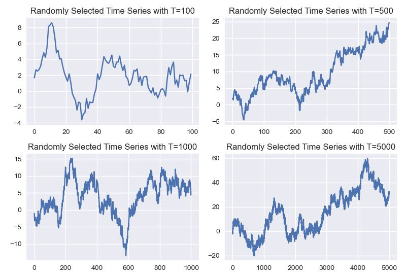

```python
# Visualize randomly selected time series
random_numbers = random.sample(range(M), 4)
figure_1, axes = plt.subplots(nrows=2, ncols=2, constrained_layout=True)
for ax, t, rand_num in zip(axes.flat, T, random_numbers):
    ax.plot(ar2_series[t][rand_num])
    ax.set_title(f'Randomly Selected Time Series with T={t}')
plt.show()
#Save the plots of one of the generated series
figure_1.savefig('Figure_1.jpg')
```

In the following analysis, I use 'adfuller' function, which is part of the 'stattools' module in the 'statsmodels.tsa package'. For more details plese see https://www.statsmodels.org/dev/generated/statsmodels.tsa.stattools.adfuller.html. Since here the main goal is to assess the influence of the sample size on the performance of the test, I forced the function to include only one lagged term in augmented DF regression.

```python
# Apply ADF test and store results
regressions = ['n', 'c', 'ct']  # types of regressions
mc_results = {t: np.array([[adfuller(ar2_series[t][i], maxlag=1, regression=reg)[0] for i in range(M)] for reg in regressions]) for t in T}
```

```python
# Assess the quantiles of the calculated t^ADF statistics
quantiles = np.array([0.01, 0.05, 0.1, 0.9, 0.95, 0.975, 0.99])
tables = {eq: np.array([[np.quantile(mc_results[t][eq, :], q) for t in T] for q in quantiles]) for eq in range(3)}
```

```python
# Print results in a loop
dash = '-' * 65
titles = ['(i)', '(ii)', '(iii)']
for eq in range(3):
    print(dash)
    print(f'{"quantiles of t - stat " + titles[eq]:^55}')
    print(dash)
    print(f'{"quant":<12} {"T=100":^12} {"T=500":^12} {"T=1000":^12} {"T=5000":^12}')
    print(dash)
    for i, q in enumerate(quantiles):
        print(f'{q:<12.2f} {tables[eq][i, 0]:^12f} {tables[eq][i, 1]:^12f} {tables[eq][i, 2]:^12f} {tables[eq][i, 3]:^12f}')
```

[output not shown]

```
-----------------------------------------------------------------
               quantiles of t - stat (i)
-----------------------------------------------------------------
quant           T=100        T=500        T=1000       T=5000
-----------------------------------------------------------------
0.01          -2.532715    -2.536557    -2.460636    -2.605144
0.05          -1.927692    -2.015485    -1.996196    -1.916696
0.10          -1.581768    -1.610561    -1.571151    -1.585726
0.90           0.938767     0.808857     0.822852     0.812436
0.95           1.284052     1.266372     1.172737     1.236855
0.97           1.712809     1.523024     1.446775     1.452174
0.99           2.224855     2.006829     2.115563     1.676534
-----------------------------------------------------------------
              quantiles of t - stat (ii)
-----------------------------------------------------------------
quant           T=100        T=500        T=1000       T=5000
-----------------------------------------------------------------
0.01          -3.467918    -3.317113    -3.447805    -3.450336
0.05          -2.898539    -2.838956    -2.864445    -2.813419
0.10          -2.564057    -2.573369    -2.568212    -2.482017
0.90          -0.353438    -0.449988    -0.436248    -0.452120
0.95           0.039573    -0.110097    -0.080792    -0.034405
0.97           0.282667     0.183731     0.315072     0.236563
0.99           0.578969     0.567898     0.539439     0.613136
-----------------------------------------------------------------
              quantiles of t - stat (iii)
-----------------------------------------------------------------
quant           T=100        T=500        T=1000       T=5000
-----------------------------------------------------------------
0.01          -4.558441    -3.996188    -3.934256    -3.929935
0.05          -3.676724    -3.293454    -3.458385    -3.358205
0.10          -3.323383    -3.067696    -3.150935    -3.082492
0.90          -1.148594    -1.276078    -1.247114    -1.162137
0.95          -0.788184    -0.959616    -0.949947    -0.951979
0.97          -0.478789    -0.662226    -0.516219    -0.548374
0.99          -0.311840    -0.374199    -0.158014    -0.098742
```

Interestingly, if we look at the quantiles of Case 2 and Case 3, we see volatile results—sometimes either too close or too far from the respective critical values. This can be due to misspecification, as the 'true' model may not include constant and intercept terms. When the wrong case is selected (i.e., unnecessary variables are included in the Dickey-Fuller regression), we do not reject the null hypothesis as often as needed, especially when the sample size is small. The reverse situation—when constant and trend terms are actually necessary but are not included—can be much more harmful, leading to a very high rate of false rejections.

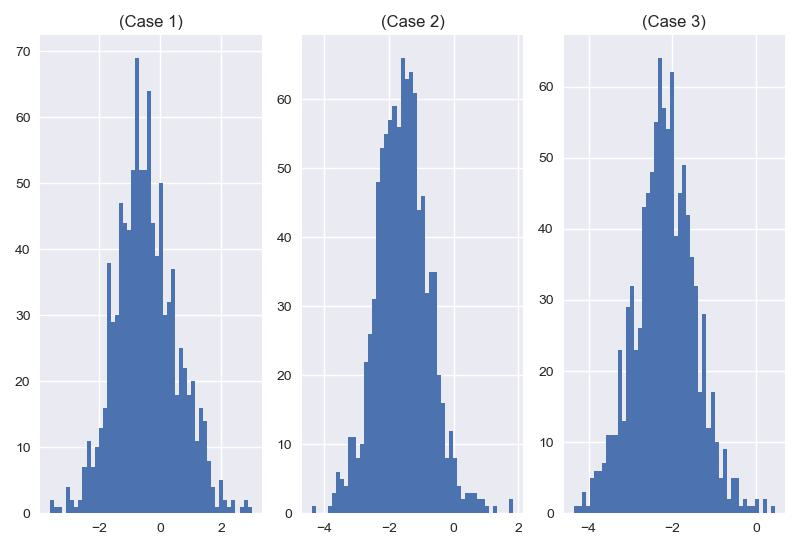

```python
# Visualize the histograms of ADF statistics
figure_2, axes = plt.subplots(nrows=1, ncols=3, constrained_layout=True)
for ax, eq, title in zip(axes, range(3), titles):
    ax.hist(mc_results[5000][eq], bins=50)
    ax.set_title(f'(Case {eq + 1})')
plt.show()
figure_2.savefig('Figure_2.jpg')
```